# Relationship

Classes are interrelated to each other in specific ways. In particular, relationships in class diagrams include different types of logical connections. The following are such types of logical connections that are possible in UML:

Types of Relationship:

1.Association

2.Aggregation

3.Composition

4.Inheritance/Generalization

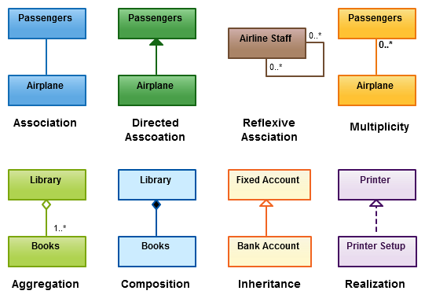

## 1.Association

Whenever an object uses another it is called an association.We use association when one object references members of the other object. Association can be uni-directional or bi-directional. We use an arrow to represent association.

**Keywords:** "Uses"

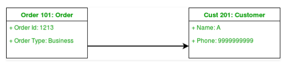

```python
class Customer:
    def __init__(self,name,phone):
        self.name=name
        self.phone=phone
class Order:
    def __init__(self,OI,OT,customer):
        self.order_id=OI
        self.order_type=OT
        self.customer=customer
    def display(self):
        print(self.customer.name)
        print(self.customer.phone)
        print(self.order_id)
        print(self.order_type)

obj=Customer("rahul",9893865085)
obj1=Order(12345,"regular",obj)
obj1.display()
```

```
rahul
9893865085
12345
regular
```

## 2.Aggregation

Aggregation is a specific form of association on relationship; aggregation is more specific than ordinary association. It is an association that represents a part-whole or part-of relationship.

Aggregation occurs when the lifecycle of the contained objects does not strongly depend on the lifecycle of container objects.

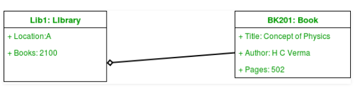

The existence of books is independent of the existence of the library.While implementing, there isn’t a lot of difference between aggregation and association. We use a hollow diamond on the containing object (container) with a line which joins it to the contained object(content).

**Keywords:** "has a"

**For example:** library has a book

```python
class Library:
    def __init__(self,location,books,b):
        self.location=location
        self.books=books
        self.b=b
    def display(self):
        print(self.location)
        print(self.books)
        print(self.b.title)
        print(self.b.author)
        print(self.b.pages)
class Book:
    def __init__(self,title,author,pages):
        self.title=title
        self.author=author
        self.pages=pages
b=Book("concept of physics","H C verma",502)
l=Library("A",2100,b)
l.display()
del l
```

```
A
2100
concept of physics
H C verma
502
```

## 3.Composition

Composition is also a special type of association. It is also a kind of parent child relationship but it is not inheritance.

Consider the example of a boy name A. A is composed of legs and arms. Here A has a composition relationship with his legs and arms. Here legs and arms cant exist without the existence of their parent object. So whenever independent existence of the child is not possible we use a composition relationship. We use a filled diamond on the containing object with a line which joins it to the contained object.

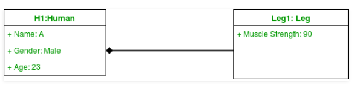

**Keywords:** "part of "

**For example:** leg is a part of human

```python
class Human:
    def __init__(self,name,gender,age):
        self.name=name
        self.gender=gender
        self.age=age
        self.leg=Leg(90)
    def display(self):
        print(self.name)
        print(self.gender)
        print(self.age)
        print(self.leg.muscle_strength)
class Leg:
    def __init__(self,muscle_strength):
        self.muscle_strength=muscle_strength
h=Human("A","male",23)
h.display()
```

```
A
male
23
90
```

## 4.Inheritance/Generalization

Refers to a type of relationship wherein one associated class is a child of another by virtue of assuming the same functionalities of the parent class. In other words, the child class is a specific type of the parent class. To show inheritance in a UML diagram, a solid line from the child class to the parent class is drawn using an unfilled arrowhead.

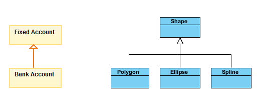

**Keywords:** "is a "

**For example:** Polygon is a shape

```python
class Shape:
    def __init__(self,no_of_pt):
        self.no_of_pt=no_of_pt
class Polygon(Shape):
    def __init__(self,no_of_pt):
        Shape.__init__(self,no_of_pt)
    def display(self):
        print("no. of side in a polygon",self.no_of_pt)
class Ellipse(Shape):
    def __init__(self,no_of_pt):
        Shape.__init__(self,no_of_pt)
    def display(self):
        print("no. of side in a Ellipse",self.no_of_pt)
class Spline(Shape):
    def __init__(self,no_of_pt):
        Shape.__init__(self,no_of_pt)
    def display(self):
        print("no. of side in a spline",self.no_of_pt)
p=Polygon(3)
p.display()
s=Spline(4)
s.display()
```

```
no. of side in a polygon 3
no. of side in a spline 4
```

# Dependency

In a dependency relationship, as the name suggests, two or more elements are dependent on each other. In this kind of a relationship, if we make a change to a particular element, then it is likely possible that all the other elements will also get affected by the change. This is a unidirectional kind of relationship between two objects.

**For example** – In the figure below, an object of Player class is dependent (or uses) an object of Bat class.

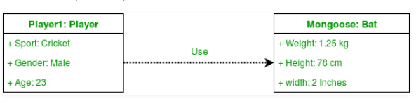

Types of Dependency:

1. Realizaton
2. Abstraction
3. Binding
4. Substitution
5. Usage

# 1. Realization

In a realization relationship of UML, one entity denotes some responsibility which is not implemented by itself and the other entity that implements them. This relationship is mostly found in the case of interfaces.

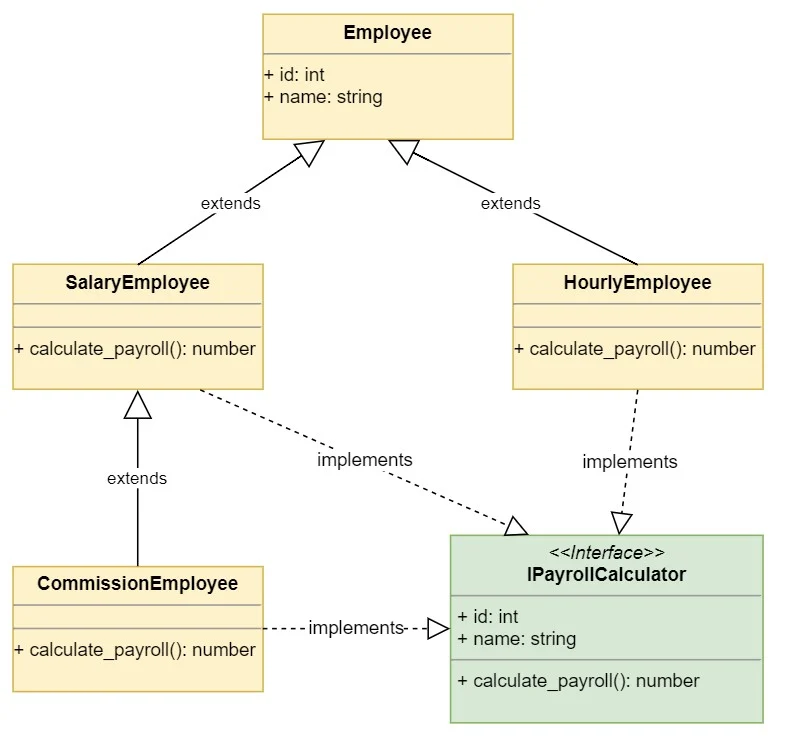

```python
class Employee:
    def __init__(self, id, name):
        self.id = id
        self.name = name

class SalaryEmployee(Employee):
    def __init__(self, id, name, monthly_salary):
        super().__init__(id, name)
        self.monthly_salary = monthly_salary

    def calculate_payroll(self):
        return self.monthly_salary

class HourlyEmployee(Employee):
    def __init__(self, id, name, hours_worked, hour_rate):
        super().__init__(id, name)
        self.hours_worked = hours_worked
        self.hour_rate = hour_rate

    def calculate_payroll(self):
        return self.hours_worked * self.hour_rate

class CommissionEmployee(SalaryEmployee):
    def __init__(self, id, name, monthly_salary, commission):
        super().__init__(id, name, monthly_salary)
        self.commission = commission

    def calculate_payroll(self):
        return self.monthly_salary + self.commission
class PayrollSystem:
    def calculate_payroll(self, employees):
        print('Calculating Payroll')
        print('===================')
        for employee in employees:
            print(employee.id, employee.name)
            print(employee.calculate_payroll())
            print('')

s = SalaryEmployee(1, 'rahul', 50000)
h = HourlyEmployee(2, 'amit', 8, 150)
c = CommissionEmployee(3, 'rohan', 60000, 2500)
payroll_system = PayrollSystem()
payroll_system.calculate_payroll([s,h,c])
```

```
Calculating Payroll
===================
1 rahul
50000

2 amit
1200

3 rohan
62500
```